# Check lengths and trim for UPARSE

Choose a sequence length threshold to use. This will actually be evaluated and used to filter and trim the reads later in the script, and will right the file to disk as a modified name of the input file. The graphic is included to help you choose/refine the length threshold. Thus, you should run this more than once (if the initial threshold is inappropriate), or run the chunks in steps and repeat that way. I prefer the former because you can keep the HTML results as a record of your parameter choices for this trimming step.

If you’d like, you can download the compressed dataset for yourself. You will need to also decompress the directory, and the sequence file.

`ftp://thebeast.colorado.edu/pub/QIIME_DB_Public_Studies/study_1688_split_library_seqs_and_mapping.tgz`

We are going to use the ShortRead package to process large (~250 MB) DNA sequence files, and the ggplot2 package to create a histogram of read lengths for this dataset.

Let’s load these packages.

```r
library("ShortRead"); packageVersion("ShortRead")
library("ggplot2"); packageVersion("ggplot2")
```

```r
LengthThreshold = 210L
outputFile = paste0("seqs-trim-", LengthThreshold,".fna")
data_dir = "qiime_overview_tutorial"
inputFile = "seqs.fna"
```

The demultiplexed 454 reads are stored in a single `.fna` file in my data archive.

```r
x = readFasta(dirPath=data_dir, pattern=inputFile)
x
```

```
## class: ShortRead
## length: 1337 reads; width: 200..260 cycles
```

There are 1337 reads provided in this dataset, with a length range of 200, 260.

We need to decide on a length threshold. UPARSE doc strongly suggests against any end-gap alignment issues by trimming sequences to some minimum length so that they are all the same. Not that this assumes that the primers, linkers, and other technical segments of the “raw” sequences have been trimmed off, so that the beginning of each read is comparable.

We need to choose a length for our sequences. Let’s explore the histogram of read lengths. `width(x)` returns an integer vector of read lengths. The following is a custom histogram plotting function that we will use several times in this script.

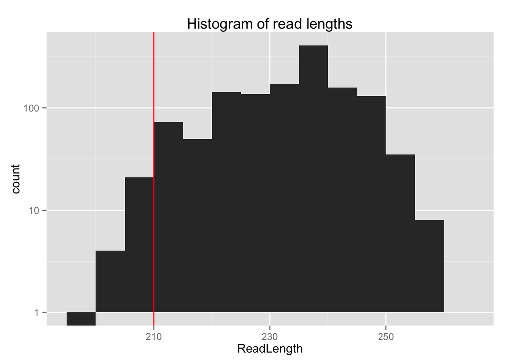

```r
plot_length_hist = function(x, LengthThreshold, binw=5L){
  require("ggplot2")
  ggplot(data.frame(ReadLength = width(x)), aes(x=ReadLength)) + geom_histogram(binwidth = binw) +
    scale_y_log10() +
    geom_vline(xintercept=LengthThreshold, color="red") + ggtitle("Histogram of read lengths")
}
plot_length_hist(x, LengthThreshold)
```

It looks like 210 nucleotides would be a good length threhold for these sequences.

First, remove reads from our ShortRead object, `x`, that are shorter in length than 210.

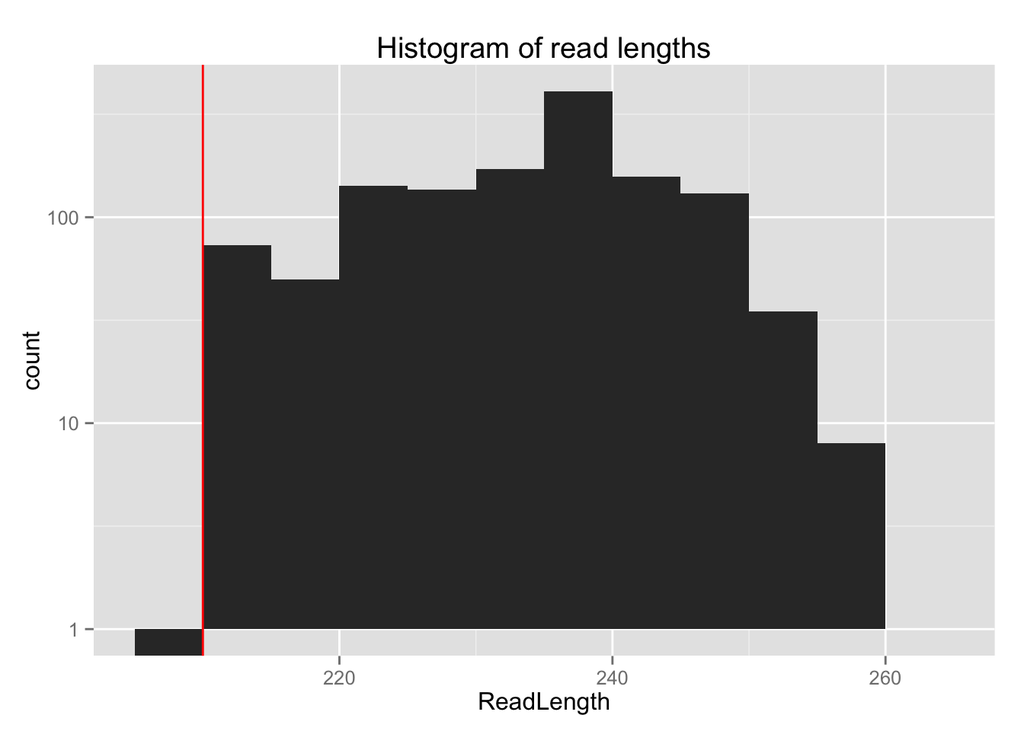

```r
xfilt = x[width(x) >= LengthThreshold]
plot_length_hist(xfilt, LengthThreshold)
```

Now, trim the ends of the remaining sequences

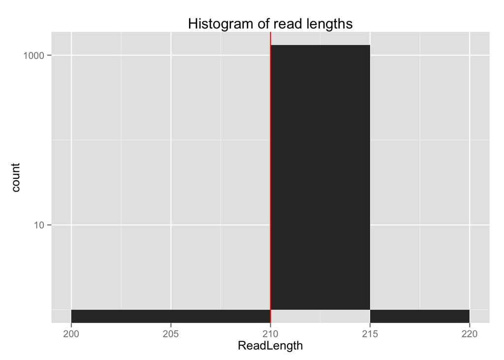

```r
xtrim = narrow(xfilt, start=1, end=LengthThreshold)
plot_length_hist(xtrim, LengthThreshold)
```

```r
xtrim
```

```
## class: ShortRead
## length: 1312 reads; width: 210 cycles
```

```r
# Remove prev version of output file, then write
outputFile = file.path(data_dir, outputFile)
unlink(outputFile)
writeFasta(object=xtrim, file=outputFile, mode="w")
```